# Class 10 : Multiple Regression Review and Some Project Funtimes

## [Check-In : Interpreting A Multivariate Regression Table](https://docs.google.com/forms/d/e/1FAIpQLSe4ksB7pNrEpdQcwRG-fOn5Ti5Q85a5ZFJwyC4EckVVhZkA6g/viewform?usp=header)

The data below are from a REAL-LIFE study, where researchers studied the relationship between Life Satisfaction, demographic variables, the number of facebook friends that a person had, and other personality variables.

These relationships were reported in the table below.

[figure not shown]

### From Regression Table to Results Section

[figure not shown]

## A Big Regression Table

The study below predicted circadian typology (time a person went to bed) from a variety of other variables.

- **ICE BREAKER :** If you could learn one skill all at once (like Neo in the Matrix; have y’all seen that movie???), what would it be??
- **Evaluate the table above and think about multiple regression.**
  - What are some patterns in the data below that seem important?
  - How would you write about these results in a final paper result section?
  - What is the multivariate regression you will include in your final project? why might this be interesting to test?

[figure not shown]

[Full Source](https://personal.lse.ac.uk/kanazawa/pdfs/paid2009.pdf)

## Optional : Chapter 12 (on Interaction Effects)

- **Key Idea :** the effect of the IV on the DV *depends on* another IV.
- **Example :** Average Time to Solve Puzzle ~ Sex * Culture + Error

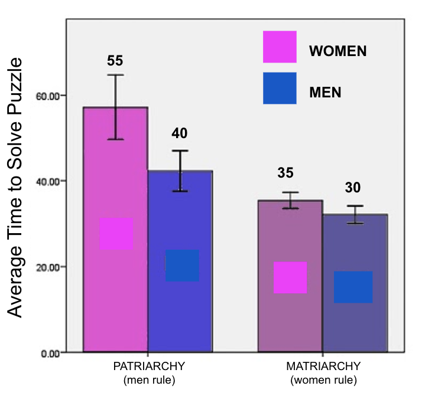

## Final Project Workshop

[figure not shown]

- Reviewing Regression Tables —> Writing Your Results
- Reviewing Introduction Outlines
- Reviewing Methods